# Week4

Sarfaraz Ahmed

August 1, 2017

# Pre-Lab 4: Austin City Limits

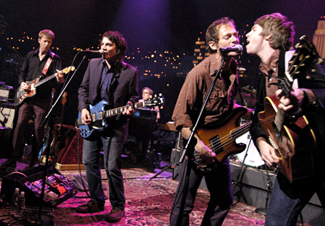

Known as the “Live Music Capital of the World,” Austin, Texas is also home to the longest-running music series in American television history, Austin City Limits. This dataset includes data on a sample of musicians that performed live on the PBS television series Austin City Limits over the last 10 years. Data on each artist include measures of commercial popularity, such as the number of social media followers on Twitter or Facebook, and their success in winning a Grammy Music Award.

Primary Research Questions

1. Are there an equal number of male and female performers on Austin City Limits?
2. Are male performers just as likely to have had a Top 10 hit as female performers?

problem 3 points possible (graded) Check the Data

Let’s begin by examining our data in R.

1. Open RStudio. Make sure you’ve installed the SDSFoundations package.
2. Type library(SDSFoundations). This will automatically load the data for the labs. 3.Type acl <- AustinCityLimits. This will assign the data to your Workspace.
3. Look at the spreadsheet view of the data to answer the following questions.

Alternatively, follow the steps in the “Importing a Data Frame” R tutorial video, and use the AustinCityLimits.csv file. (Right-click and “Save As.”) Make sure to name the dataframe “acl” when importing.

1. Open RStudio.
2. Click on the “Import Dataset” button at the top of the workspace window. Choose “from text file.”
3. Click on the location of the AustinCityLimits.csv file you just downloaded.
4. Click on the AustinCityLimits.csv file. Then, click Upload.
5. Look at the spreadsheet view of the data to answer the following questions.

```r
library(SDSFoundations)

acl <- AustinCityLimits
```

1a. In what year did Allen Toussaint play at Austin City Limits?

2009 correct 2009 1b. How many years old was Allen Toussaint when he performed?

75 correct 75 1c. How many variables for Allen Toussaint have missing data?

1 correct 1 Submit You have used 1 of 1 attempt Some problems have options such as save, reset, hints, or show answer. These options follow the Submit button.

Show Answer Correct (3/3 points) Review problem 3/4 points (graded) Check the Variables of Interest

Let’s find the variables we need to answer the question.

2a. Which variable tells us whether the performer is male or female?

The variable name in the dataset is correctGender , which is a correctcategorical variable.

2b. Which variable tells us whether the artist has had a Top 10 hit?

The variable name in the dataset is correctBB.wk.top10 ,which is a unsubmittedcategorical variable. Click here for a video explanation of how to answer this question. Submit You have used 1 of 1 attempt Some problems have options such as save, reset, hints, or show answer. These options follow the Submit button.

Show Answer Answers are displayed within the problem Review problem 2/2 points (graded) Reflect on the Method

Which method should we be using for this analysis and why?

3a. We will use a Chi Square Goodness of Fit test to check whether there were an equal number of male and female performers. Why?

We want to see if the distribution of a categorical variable matches a proposed distribution model. correct We want to know if there is an association between two categorical variables. 3b. We will use a Chi Square Test of Independence to determine if male and female performers were equally likely to have had a Top 10 hit. Why?

We want to determine if there is an association between two categorical variables. correct We want to compare the distribution of a categorical variable to a proposed distribution model.

Primary Research Questions

1. Are there an equal number of male and female performers on Austin City Limits?
2. Are male performers just as likely to have had a Top 10 hit as female performers?

Breakdown Your Analysis

Let’s break this analysis into its required steps:

Goodness of Fit Test: 1. Make a table of counts for gender. 2. Create a vector of the expected proportions. 3. Check the expected counts assumption. 4. Run the chi square test. 5. Interpret the chi square statistic and p-value.

Test of Independence: 1. Create a two-way table for gender and Top 10 hits. 2. Check the expected counts assumption. 3. Run the chi square test. 4. Interpret the chi square statistic and p-value.

Here is the code you will use:

Question 1 (Goodness of Fit)

```r
# Create a table of counts for Gender
gender_tab <-table(acl$Gender)
gender_tab
```

```
##
##  F  M
## 35 81
```

```r
# Create vector of expected proportions
ExpGender <- c(.50, .50)

# Check expected counts assumption
chisq.test(gender_tab, p=ExpGender)$expected
```

```
##  F  M
## 58 58
```

```r
# Run goodness of fit
chisq.test(gender_tab, p=ExpGender)
```

```
##
##  Chi-squared test for given probabilities
##
## data:  gender_tab
## X-squared = 18.241, df = 1, p-value = 1.946e-05
```

Question 2 (Test of Independence)

```r
# Create two-way table
gender_top10 <-table(acl$Gender, acl$BB.wk.top10)
gender_top10
```

```
##
##      0  1
##   F 15 18
##   M 38 32
```

```r
# Generate expected counts
chisq.test(gender_top10, correct=FALSE)$expected
```

```
##
##            0        1
##   F 16.98058 16.01942
##   M 36.01942 33.98058
```

```r
# Run test of independence
chisq.test(gender_top10, correct=FALSE)
```

```
##
##  Pearson's Chi-squared test
##
## data:  gender_top10
## X-squared = 0.70023, df = 1, p-value = 0.4027
```

problem 1/1 point (graded) 1. If we wanted to test the hypothesis that the performers were 30% female and 70% male, what would the code look like? (Note that categorical values are referenced in alphabetical order).

ExpGender <- c(.70, .30) ExpGender <- c(.30,.70) correct ExpGender <- c(.50, .50) Submit You have used 1 of 1 attempt Some problems have options such as save, reset, hints, or show answer. These options follow the Submit button.

Show Answer Correct (1/1 point) Review problem 0/1 point (graded) 2. Suppose the following values were returned for the “check expected counts” assumption in our goodness of fit test. Would the assumption be violated?

F M

3 29

No, because the total number of expected counts is greater than 5. incorrect Yes, because there are fewer females than males expected, and the test proportion is 50/50. Yes, because there are fewer than 5 expected Females. correct Click here for a video explanation of how to answer this question. Submit You have used 1 of 1 attempt Some problems have options such as save, reset, hints, or show answer. These options follow the Submit button.

Show Answer Answers are displayed within the problem Review problem 1/1 point (graded) 3. Which line of code is not necessary for a test of independence because there is no particular distribution model being tested?

gender_top10 <-table(acl$Gender, acl$BB.wk.top10) ExpGender_top10 <- c(.25, .25, .25, .25) correct chisq.test(gender_top10, correct=FALSE) Submit You have used 1 of 1 attempt Some problems have options such as save, reset, hints, or show answer. These options follow the Submit button.

Show Answer Correct (1/1 point) Review problem 1/1 point (graded) 4. How many degrees of freedom should there be for our test of independence? Remember, performers have either had (or not had) a Top 10 hit.

1 correct 2 3 Submit You have used 1 of 1 attempt Some problems have options such as save, reset, hints, or show answer. These options follow the Submit button.

Show Answer Correct (1/1 point) Review problem 1/1 point (graded) Suppose we wanted to test whether there was an even distribution among the seasons. What caused the following error below? (You may want to examine the dataset in R for help.)

acl <- AustinCityLimits season_counts <- table(acl$Season) ExpSeason <- c(1/4, 1/4, 1/4, 1/4) chisq.test(season_counts, p=ExpSeason)

Error in chisq.test(season_counts, p = ExpSeason) : ‘x’ and ‘p’ must have the same number of elements The probabilities in line 3 need to be expressed as decimals instead of fractions. We ran the wrong Chi Square test. There are not 4 seasons in our dataset, although line 3 suggests that there are. correct The variable “Season” is not capitalized in our dataset.

Primary Research Questions

1. Are there an equal number of male and female performers on Austin City Limits?
2. Are male performers just as likely to have had a Top 10 hit as female performers?

Conduct the Analysis in R

1. Type or copy the script from the Prepare for the Analysis section into the Script window of R.
2. Select the portion of the code you wish to run, then press “ctrl+ enter.”
3. Output can be found in the Console window.

problem 5/5 points (graded) Goodness of Fit Test

Use the output of your analysis to answer the following questions.

1a. There were ________ male and 35 female artists.

81 correct 81 1b. The expected counts were ________ artists of each gender.

58 correct 58 1c. Chi Square (rounded to 2 decimal places, with df=1)=

18.24 correct 18.24 1d. The p-value was _______ 0.05.

correct 1e. We should ________ the hypothesis that there were an equal number of male and female performers at ACL Live.

correct Submit You have used 1 of 1 attempt Some problems have options such as save, reset, hints, or show answer. These options follow the Submit button.

Show Answer Correct (5/5 points) Review problem 5/6 points (graded) Test of Independence

Use the output of your analysis to answer the following questions.

2a. Among the male artists, _______ out of 70 had a Top 10 hit.

32 correct32 32 2b. Among the female artists, _______ out of 33 had a Top 10 hit.

18 correct18 18 2c. Based on these values, there must have been _________ males and 2 females with missing values for the Top 10 variable.

11 correct11 11 2d. Chi Square (rounded to 3 decimal places, df=1)=

0.700 correct0.700 0.700 2e. p-value (rounded to 3 decimal places)=

0.403 correct.403 0.403 2f. We should ______ the hypothesis that gender is not associated with having a Top 10 hit.

incorrectfail to reject Click here for a video explanation of how to answer this question. Submit You have used 1 of 1 attempt Some problems have options such as save, reset, hints, or show answer. These options follow the Submit button.

Show Answer Answers are displayed within the problem Review problem 1/1 point (graded) 3. Was the expected counts assumption violated in either of these chi square tests?

It was violated in the test of independence. It was not violated in either test. correct It was violated in both tests. It was violated in the goodness of fit test.

Primary Research Questions

1. Are there an equal number of male and female performers on Austin City Limits?
2. Are male performers just as likely to have had a Top 10 hit as female performers?

problem 10/13 points (graded) Write Your Conclusion

Answer the question and support your answer with statistics:

First we examined whether there were an equal number of male and female artists on Austin City Limits. In our sample, there were 81 correctmales and 35 correctfemales . A chi square correctgoodness of fit test showed that this difference correctwas statistically significant (chi square= correct18.24 df=1, p<.05). There are more correctmales than correctfemales on the show. Second, we asked whether male and female artists were equally likely to have had a Top 10 hit. Approximately 55% of the incorrectfemale artists had a Top 10 hit, and 46% of the incorrectmale artists had a Top 10 hit. This difference correctwas not statistically significant. A chi square test of independence found top 10 hits to be incorrectindependent of gender (chi square= 0.700, df=1, p= correct0.403 ). The assumptions for each test correctwere met.

# Lab 4: Austin City Limits

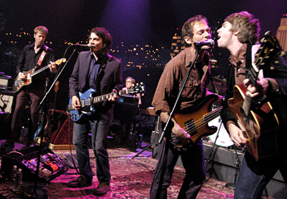

Known as the “Live Music Capital of the World,” Austin, Texas is also home to the longest-running music series in American television history, Austin City Limits. This dataset includes data on a sample of musicians that performed live on the PBS television series Austin City Limits over the last 10 years. Data on each artist include measures of commercial popularity, such as the number of social media followers on Twitter or Facebook, and their success in winning a Grammy Music Award.

problem 2/2 points (graded) Review of Chi Square Tests

In this lab, you will use Chi Square Tests to answer a question of interest. Let’s start by remembering why we use each Chi Square test.

1a. In a Chi Square Goodness of Fit test, a proposed distribution model is compared to an observed

marginal distribution. correct mean. conditional distribution. set of variables. 1b. Two categorical variables are said to be independent if their conditional distribution matches

the marginal distribution of one of the variables. the distribution of expected counts, when the variables are assumed not to be related. correct the distribution of expected counts, where the counts are the same in every cell. Submit You have used 1 of 1 attempt Some problems have options such as save, reset, hints, or show answer. These options follow the Submit button.

Show Answer Correct (2/2 points) Review problem 2/2 points (graded) Lab Preparation

In this lab you will be working with data from the Austin City Limits.

1. Open RStudio. Make sure you’ve installed the SDSFoundations package.
2. Type library(SDSFoundations). This will automatically load the data for the labs. 3.Type acl <- AustinCityLimits. This will assign the data to your Workspace.

Alternatively, you can use follow the steps in the “Importing a Data Frame” R tutorial video, and use the AustinCityLimits.csv file. (Right-click and “Save As.”) Make sure to name the dataframe “acl” when importing.

1. Open RStudio.
2. Click on the “Import Dataset” button at the top of the workspace window. Choose “from text file.”
3. Click on the location of the AustinCityLimits.csv file you just downloaded.
4. Click on the AustinCityLimits.csv file. Then, click Upload.

Feel free to use the script from the week’s PreLab, which you can modify for use in this Lab.

The following two questions will be answered in lab. Match each question to its appropriate Chi Square test.

2a. Are each of the four musical genres equally represented on Austin City Limits?

correctgoodness of fit test 2b. Are some genres more likely to draw a large (100K+) Twitter following than others?

correcttest of independence

Primary Research Questions

1. Are each of the four musical genres equally represented on Austin City Limits?
2. Are some genres more likely to draw a large (100K+) Twitter following than others?

Analysis

Let’s break this question down into the different descriptive statistics that you will need to construct your answer. Be sure that your R output includes all of the following components.

Goodness of Fit Test: 1. Create a table to show the counts of each genre. 2. Create a vector of expected proportions. 3. Check the expected counts assumption. 4. Run a chi square test. 5. Interpret the chi square statistic and p-value.

Test of Independence: 1. Create a two-way table for genre and Twitter following. 2. Check the expected counts assumption. 3. Run a chi square test. 4. Interpret the chi square statistic and p-value.

Question 1 (Goodness of Fit)

```r
# Create a table of counts for Gender
genre_tab <-table(acl$Genre)
genre_tab
```

```
##
##           Country        Jazz/Blues   Rock/Folk/Indie Singer-Songwriter
##                18                13                68                17
```

```r
# Create vector of expected proportions
ExpGenre <- c(.25, .25, .25, .25)

# Check expected counts assumption
chisq.test(genre_tab, p=ExpGenre)$expected
```

```
##           Country        Jazz/Blues   Rock/Folk/Indie Singer-Songwriter
##                29                29                29                29
```

```r
# Run goodness of fit
chisq.test(genre_tab, p=ExpGenre)
```

```
##
##  Chi-squared test for given probabilities
##
## data:  genre_tab
## X-squared = 70.414, df = 3, p-value = 3.481e-15
```

Question 2 (Test of Independence)

```r
# Create two-way table
genre_twitter <-table(acl$Genre, acl$Twitter.100k)
genre_twitter
```

```
##
##                      0  1
##   Country           11  6
##   Jazz/Blues         9  2
##   Rock/Folk/Indie   33 26
##   Singer-Songwriter  6 10
```

```r
prop.table(genre_twitter, 1)
```

```
##
##                             0         1
##   Country           0.6470588 0.3529412
##   Jazz/Blues        0.8181818 0.1818182
##   Rock/Folk/Indie   0.5593220 0.4406780
##   Singer-Songwriter 0.3750000 0.6250000
```

```r
# Generate expected counts
chisq.test(genre_twitter, correct=FALSE)$expected
```

```
##
##                             0         1
##   Country            9.737864  7.262136
##   Jazz/Blues         6.300971  4.699029
##   Rock/Folk/Indie   33.796117 25.203883
##   Singer-Songwriter  9.165049  6.834951
```

```r
# Run test of independence
chisq.test(genre_twitter, correct=FALSE)
```

```
##
##  Pearson's Chi-squared test
##
## data:  genre_twitter
## X-squared = 5.6919, df = 3, p-value = 0.1276
```

problem 4/4 points (graded) Goodness of Fit Test

1a. What was the expected count of artists for each genre?

29 correct 29 1b. What was the Chi-square statistic? (round to 2 decimal places)

70.41 correct 70.41 1c. How many degrees of freedom?

3 correct 3 1d. What was the p-value?

correct Submit You have used 1 of 1 attempt Some problems have options such as save, reset, hints, or show answer. These options follow the Submit button.

Show Answer Correct (4/4 points) Review problem 3/7 points (graded) Test of Independence

2a. Using the data from your two-way table, compute the proportion of artists in each genre with 100K+ Twitter followers. (Round to 3 decimal places).

5.69 correct5.69 5.69 2c. How many degrees of freedom?

3 correct3 3 2d. What was the p-value?

correctgreater than 0.05 Submit You have used 1 of 1 attempt Some problems have options such as save, reset, hints, or show answer. These options follow the Submit button.

Show Answer Answers are displayed within the problem Review problem 2/2 points (graded) Conclusions

3a. We should correctreject the hypothesis that each genre is equally represented at ACL Live.

3b. We should correctfail to reject the hypothesis that genre is independent of Twitter followers.

Primary Research Questions

1. Are each of the four musical genres equally represented on Austin City Limits?
2. Are some genres more likely to draw a large (100K+) Twitter following than others?

problem 8/9 points (graded) Write Your Conclusion

Answer the question and support your answer with statistics:

First we examined whether genres were represented equally at Austin City Limits. In our sample, there were 18 country, 13 jazz/blues, 68 rock/folk/indie, and 17 singer/songwriter acts. A Chi-square correctGoodness of Fit test showed that this difference correctwas statistically significant. (Chi-square= correct70.41 , df= correct3 , p<0.05). There is a higher representation of incorrectrock/folk/indie artists than other artists on the show.

Second, we asked whether some genres were likely to draw more Twitter (over 100K). A Chi-square correctTest of Independence revealed that there was no significant finding–a large Twitter following was correctindependent of genre (Chi-square= correct5.69 , df= correct3 , p-value=0.1276).

## Problem Set

Question 1

You want to know if the proportion of female performers on Austin City Limits Live has changed in the past two years.

1. Create a new variable in the dataset called “Recent” that is equal to a 1 for rows from years 2012 or 2013 and is equal to 0 for all other rows.
2. Make a table that shows the number of male and female performers in “recent” and non-recent years.
3. Use this data to answer the following questions.

Use the “AustinCityLimits.csv” dataset to answer the following questions. Instructions for installing “AustinCityLimits.csv” can be found under the Examine the Data unit in this week’s Pre-Lab section.

You’ll need to use the following code to help: `acl$Recent[acl$Year < 2012] <- 0` `acl$Recent[acl$Year >= 2012] <- 1`

```r
acl$Recent[acl$Year < 2012] <- 0
acl$Recent[acl$Year >= 2012] <- 1

Gender_recent <- table(acl$Gender, acl$Recent)

chisq.test(Gender_recent)$expected
```

```
##
##            0         1
##   F 26.55172  8.448276
##   M 61.44828 19.551724
```

```r
chisq.test(Gender_recent, correct = F)
```

```
##
##  Pearson's Chi-squared test
##
## data:  Gender_recent
## X-squared = 2.8188, df = 1, p-value = 0.09317
```

problem 1/1 point (graded) 1a. How many female performers have been on the show in the past two years (2012 and 2013)?

12 correct 12 Submit You have used 1 of 1 attempt Some problems have options such as save, reset, hints, or show answer. These options follow the Submit button.

Show Answer Correct (1/1 point) Review problem 0/1 point (graded) 1b. What is the appropriate method to test if representation by female performers is different before 2012 compared to since 2012?

Chi-Square Goodness of Fit incorrect Chi-Square Test of Independence correct t-test for Independent Samples t-test for Dependent Samples Submit You have used 1 of 1 attempt Some problems have options such as save, reset, hints, or show answer. These options follow the Submit button.

Show Answer Answers are displayed within the problem Review problem 1/1 point (graded) 1c. Report expected counts for the following performer groups.

Females before 2012

correct Submit You have used 1 of 1 attempt Some problems have options such as save, reset, hints, or show answer. These options follow the Submit button.

Show Answer Correct (1/1 point) Review problem 1/1 point (graded) Females in 2012 and 2013

correct Submit You have used 1 of 1 attempt Some problems have options such as save, reset, hints, or show answer. These options follow the Submit button.

Show Answer Correct (1/1 point) Review problem 1/1 point (graded) Males before 2012

correct Submit You have used 1 of 1 attempt Some problems have options such as save, reset, hints, or show answer. These options follow the Submit button.

Show Answer Correct (1/1 point) Review problem 1/1 point (graded) Males in 2012 and 2013

correct Submit You have used 1 of 1 attempt Some problems have options such as save, reset, hints, or show answer. These options follow the Submit button.

Show Answer Correct (1/1 point) Review problem 0/1 point (graded) 1d. What is the Chi Square statistic? (Round to 2 decimal places.)

Show Answer Answers are displayed within the problem Review problem 1/1 point (graded) 1e. What is the p-value for the test? (Round to 2 decimal places.)

0.09 correct 0.09 Submit You have used 1 of 1 attempt Some problems have options such as save, reset, hints, or show answer. These options follow the Submit button.

Show Answer Correct (1/1 point) Review problem 1/1 point (graded) 1f. What is the appropriate conclusion for this test, assuming α = 0.05?

We fail to reject the null hypothesis; gender is independent of performance before or after 2012. correct We reject the null hypothesis; gender is not independent of performance before or after 2012

Question 2

When crossing white and yellow summer squash, a genetic model predicts that 75% of resulting offspring will be white, 15% will be yellow and 10% will be green.

Below are the results from an experiment run on a random sample of 205 squash offspring.

Color White Yellow Green Number of Offspring 152 39 14 problem 1/1 point (graded) 2a. Which method should we use to test if these data are consistent with the ratio of offspring colors predicted by the genetic model?

Chi Square Goodness of Fit Test correct Chi Square Test of Independence Single Sample t-test Independent Samples t-test Submit You have used 1 of 1 attempt Some problems have options such as save, reset, hints, or show answer. These options follow the Submit button.

Show Answer Correct (1/1 point) Review problem 1/1 point (graded) 2b. What is the expected count of white offspring? (Round to 2 decimal places.)

153.75 correct 153.75 Submit You have used 1 of 1 attempt Some problems have options such as save, reset, hints, or show answer. These options follow the Submit button.

Show Answer Correct (1/1 point) Review problem 1/1 point (graded) 2c. What is the expected count of yellow offspring? (Round to 2 decimal places.)

30.75 correct 30.75 Submit You have used 1 of 1 attempt Some problems have options such as save, reset, hints, or show answer. These options follow the Submit button.

Show Answer Correct (1/1 point) Review problem 1/1 point (graded) 2d. What is the expected count of green offspring? (Round to 2 decimal places.)

20.5 correct 20.5 Submit You have used 1 of 1 attempt Some problems have options such as save, reset, hints, or show answer. These options follow the Submit button.

Show Answer Correct (1/1 point) Review problem 1/1 point (graded) 2e. Is the sample size condition met?

Yes correct No Submit You have used 1 of 1 attempt Some problems have options such as save, reset, hints, or show answer. These options follow the Submit button.

Show Answer Correct (1/1 point) Review problem 1/1 point (graded) 2f. What are the degrees of freedom and the critical value for this test, assuming α = 0.05?

Degrees of Freedom

2 correct 2 Submit You have used 1 of 1 attempt Some problems have options such as save, reset, hints, or show answer. These options follow the Submit button.

Show Answer Correct (1/1 point) Review problem 0/1 point (graded) Critical Value for alpha=.05: (Round to 2 decimal places.)

2.92 incorrect5.99 2.92 Submit You have used 1 of 1 attempt Some problems have options such as save, reset, hints, or show answer. These options follow the Submit button.

Show Answer Answers are displayed within the problem Review problem 1/1 point (graded) 2g. What is the Chi Square statistic for this test? (Round to 2 decimal places.)

4.29 correct 4.29 Submit You have used 1 of 1 attempt Some problems have options such as save, reset, hints, or show answer. These options follow the Submit button.

Show Answer Correct (1/1 point) Review problem 1/1 point (graded) 2h. What is the appropriate outcome for this hypothesis test?

Reject the null hypothesis Fail to reject the null hypothesis correct

```r
Q3 <- data.frame(ID = 1:21, Gender = c('M', 'M', 'F', 'M', 'F', 'F', 'F', 'M', 'F', 'F', 'M', 'F', 'M', 'M', 'F', 'M', 'M', 'F', 'F', 'M', 'F'),
                 DominantHand = c('L', 'R', 'R', 'R', 'R', 'L', 'L', 'R', 'R', 'R', 'L', 'R', 'R', 'R', 'R', 'R', 'R', 'R', 'L', 'R', 'R'))

Q3
```

```
##    ID Gender DominantHand
## 1   1      M            L
## 2   2      M            R
## 3   3      F            R
## 4   4      M            R
## 5   5      F            R
## 6   6      F            L
## 7   7      F            L
## 8   8      M            R
## 9   9      F            R
## 10 10      F            R
## 11 11      M            L
## 12 12      F            R
## 13 13      M            R
## 14 14      M            R
## 15 15      F            R
## 16 16      M            R
## 17 17      M            R
## 18 18      F            R
## 19 19      F            L
## 20 20      M            R
## 21 21      F            R
```

```r
qchisq(0.95, 1)
```

```
## [1] 3.841459
```

```r
Q3_Table <- table(Q3$Gender, Q3$DominantHand)
Q3_Table
```

```
##
##     L R
##   F 3 8
##   M 2 8
```

```r
chisq.test(Q3_Table, correct = F)$expected
```

```
##
##            L        R
##   F 2.619048 8.380952
##   M 2.380952 7.619048
```

Question 3

Approximately 13% of the world’s population is left-handed, but is this proportion the same across men and women?

To answer this question, you decide to collect data from a random sample of adults from your neighborhood, with the following results:

ID Gender Dominant Hand 1 M L 2 M R 3 F R 4 M R 5 F R 6 F L 7 F L 8 M R 9 F R 10 F R 11 M L 12 F R 13 M R 14 M R 15 F R 16 M R 17 M R 18 F R 19 F L 20 M R 21 F R problem 1/1 point (graded) 3a. Which of these is the appropriate null hypothesis for this test?

Gender and hand-dominance are independent. correct Gender and hand-dominance are NOT independent Submit You have used 1 of 1 attempt Some problems have options such as save, reset, hints, or show answer. These options follow the Submit button.

Show Answer Correct (1/1 point) Review problem 1/1 point (graded) 3b. What would be the estimated degrees of freedom and the critical value for this analysis, assuming α = 0.05?

Degrees of Freedom

1 correct 1 Submit You have used 1 of 1 attempt Some problems have options such as save, reset, hints, or show answer. These options follow the Submit button.

Show Answer Correct (1/1 point) Review problem 1/1 point (graded) Critical Value(Round to 2 decimal places.)

3.84 correct 3.84 Submit You have used 1 of 1 attempt Some problems have options such as save, reset, hints, or show answer. These options follow the Submit button.

Show Answer Correct (1/1 point) Review problem 0/1 point (graded) 3c. What are the expected counts for Males? (Round to 2 decimal places.)

Left-handed Males

Show Answer Answers are displayed within the problem Review problem 0/1 point (graded) Right-handed Males(Round to 2 decimal places.)

Show Answer Answers are displayed within the problem Review problem 1/1 point (graded) 3d. What are the expected counts for Females? (Round to 2 decimal places.)

Left-handed Females

2.62 correct 2.62 Submit You have used 1 of 1 attempt Some problems have options such as save, reset, hints, or show answer. These options follow the Submit button.

Show Answer Correct (1/1 point) Review problem 1/1 point (graded) Right-handed Females(Round to 2 decimal places.)

8.38 correct 8.38 Submit You have used 1 of 1 attempt Some problems have options such as save, reset, hints, or show answer. These options follow the Submit button.

Show Answer Correct (1/1 point) Review problem 1/1 point (graded) 3e. Are all relevant conditions met to run this analysis?

Yes No correct

```r
Q4 <- data.frame(Community = c(rep("Rural", 28), rep("Suburban", 42), rep("Urban", 53)))
Q4$Internet <- 0
Q4$Internet[Q4$Community == "Rural"][1:13] <- 1
Q4$Internet[Q4$Community == "Suburban"][1:35] <- 1
Q4$Internet[Q4$Community == "Urban"][1:50] <- 1

Q4_Table <- table(Q4)
Q4_Table
```

```
##           Internet
## Community   0  1
##   Rural    15 13
##   Suburban  7 35
##   Urban     3 50
```

```r
Q4_Table2 <- prop.table(Q4_Table)

chisq.test(Q4_Table2, correct = F)
```

```
##
##  Pearson's Chi-squared test
##
## data:  Q4_Table2
## X-squared = 0.21542, df = 2, p-value = 0.8979
```

Question 4

A telephone survey asked a random sample of Indiana voters about their home internet usage, as well as what type of community (rural, suburban or urban) they lived in.

Of the 123 survey respondents, 28 were from rural areas, 42 were from suburban areas, and 53 were from urban areas. Thirteen rural respondents, 35 suburban respondents, and 50 urban respondents said they had access to internet at home.

problem 1/1 point (graded) 4a. What is the appropriate null hypothesis for this test?

Home internet access and community type are independent. correct Home internet access and community type are not independent. Submit You have used 1 of 1 attempt Some problems have options such as save, reset, hints, or show answer. These options follow the Submit button.

Show Answer Correct (1/1 point) Review problem 1/1 point (graded) 4b. What proportion of respondents had internet access at home? (Round to 3 decimal places.)

0.797 correct 0.797 Submit You have used 1 of 1 attempt Some problems have options such as save, reset, hints, or show answer. These options follow the Submit button.

Show Answer Correct (1/1 point) Review problem 1/1 point (graded) 4c. What proportion of respondents did NOT have internet access at home? (Round to 3 decimal places.)

0.203 correct 0.203 Submit You have used 1 of 1 attempt Some problems have options such as save, reset, hints, or show answer. These options follow the Submit button.

Show Answer Correct (1/1 point) Review problem 0/1 point (graded) 4d. How many rural residents would we expect to have home internet? Please use a rounded proportion you calculated above. (Round to 2 decimal places.)

Show Answer Answers are displayed within the problem Review problem 1/1 point (graded) 4e. How many urban residents would we expect NOT to have home internet? Please use a rounded proportion you calculated above. (Round to 2 decimal places.)

10.76 correct 10.76 Submit You have used 1 of 1 attempt Some problems have options such as save, reset, hints, or show answer. These options follow the Submit button.

Show Answer Correct (1/1 point) Review problem 1/1 point (graded) 4f. Does this data provide sufficient evidence that internet access at home depends on what type of community the Indiana voters live in?